# E16.5 mouse dentate gyrus

```r
library(COTAN)
library(data.table)
library(Matrix)
library(ggrepel)
library(latex2exp)
```

```r
mycolours <- c("A" = "#8491B4B2","B"="#E64B35FF")
my_theme = theme(axis.text.x = element_text(size = 14, angle = 0, hjust = .5, vjust = .5, face = "plain", colour ="#3C5488FF" ),
                 axis.text.y = element_text( size = 14, angle = 0, hjust = 0, vjust = .5, face = "plain", colour ="#3C5488FF"),
                 axis.title.x = element_text( size = 14, angle = 0, hjust = .5, vjust = 0, face = "plain", colour ="#3C5488FF"),
                 axis.title.y = element_text( size = 14, angle = 90, hjust = .5, vjust = .5, face = "plain", colour ="#3C5488FF"))
```

```r
data_dir = "Data/mouse_dentate_gyrus/"
```

```r
data = as.data.frame(fread(paste(data_dir,"separation_age/E16.5.csv", sep = "/")))
data = as.data.frame(data)
rownames(data) = data$V1
data = data[,2:ncol(data)]
data[1:10,1:10]
```

|  | X10X82_1_CAGAACAAGTTCTG. | X10X82_1_TCACTTCTCGCATC. | X10X82_1_TCACTCATATGCTG. | X10X82_1_ATGGCTCACGCGGT. | X10X82_1_GGTGCCAACGCACC. | X10X82_1_TGAGTTCAAGCCTA. | X10X82_1_CACGATCGCGTTTC. | X10X82_1_TATGCGTCCGCTGA. | X10X82_1_TGCTATCGGAAACG. | X10X82_1_GTTAGAGCGCTTAT. |
| --- | --- | --- | --- | --- | --- | --- | --- | --- | --- | --- |
| 0610007P14Rik | 4 | 1 | 1 | 1 | 3 | 1 | 2 | 0 | 2 | 4 |
| 0610009B22Rik | 1 | 1 | 0 | 1 | 1 | 1 | 0 | 2 | 0 | 0 |
| 0610009L18Rik | 0 | 0 | 0 | 1 | 0 | 0 | 0 | 0 | 0 | 0 |
| 0610009O20Rik | 2 | 0 | 0 | 0 | 0 | 0 | 0 | 0 | 0 | 0 |
| 0610010F05Rik | 0 | 1 | 0 | 0 | 0 | 1 | 1 | 0 | 0 | 0 |
| 0610010K14Rik | 4 | 0 | 0 | 1 | 0 | 0 | 0 | 0 | 0 | 1 |
| 0610011F06Rik | 0 | 0 | 1 | 1 | 1 | 0 | 1 | 0 | 0 | 1 |
| 0610012D04Rik | 0 | 0 | 0 | 0 | 0 | 0 | 0 | 0 | 0 | 0 |
| 0610012G03Rik | 4 | 1 | 3 | 2 | 1 | 2 | 1 | 3 | 1 | 2 |
| 0610025J13Rik | 0 | 0 | 0 | 0 | 0 | 0 | 1 | 0 | 0 | 0 |

Define a directory where the ouput will be stored.

```r
out_dir = "Data/"
```

## 0.1 Analitical pipeline

Inizialise the COTAN object with the row count table and the metadata for the experiment.

```r
obj = new("scCOTAN",raw = data)
obj = initRaw(obj,GEO="GSE104323" ,sc.method="10X",cond = "mouse dentate gyrus E16.5")
```

```
[1] "Initializing S4 object"
```

Now we can start the cleaning. Analysis requires and starts from a matrix of raw UMI counts after removing possible cell doublets or multiplets and low quality or dying cells (with too high mtRNA percentage, easily done with Seurat or other tools).

If we do not want to consider the mithocondrial genes we can remove them before starting the analysis.

```r
genes_to_rem = rownames(obj@raw[grep('^mt', rownames(obj@raw)),]) #genes to remove : mithocondrial
obj@raw = obj@raw[!rownames(obj@raw) %in% genes_to_rem,]
cells_to_rem = colnames(obj@raw[which(colSums(obj@raw) == 0)])
obj@raw = obj@raw[,!colnames(obj@raw) %in% cells_to_rem]
```

We want also to define a prefix to identify the sample.

```r
t = "E16.5_cleaned"

print(paste("Condition ",t,sep = ""))
```

```
[1] "Condition E16.5_cleaned"
```

```r
#--------------------------------------
n_cells = length(colnames(obj@raw))
print(paste("n cells", n_cells, sep = " "))
```

```
[1] "n cells 2285"
```

```r
n_it = 1

#obj@raw = obj@raw[rownames(cells), colnames(cells)]
```

## 0.2 Data cleaning

First we create the directory to store all information regardin the data cleaning.

```r
if(!file.exists(out_dir)){
  dir.create(file.path(out_dir))
}

if(!file.exists(paste(out_dir,"cleaning", sep = ""))){
  dir.create(file.path(out_dir, "cleaning"))
}
```

```r
ttm = clean(obj)
```

```
[1] "Start estimation mu with linear method"
[1] 14131  2285
```

|  | rowname | X10X82_1_TACTGAGGCATGGT. |
| --- | --- | --- |
| 9692 | Ptgds | 910.01759 |
| 7119 | Malat1 | 144.82597 |
| 8232 | Nnat | 56.04377 |
| 4619 | Ftl1 | 52.71443 |
| 1127 | Apoe | 44.94599 |
| 1404 | Atp1a2 | 43.83621 |
| 2343 | Cdkn1c | 38.84221 |
| 2840 | Cox4i1 | 32.73844 |
| 2854 | Cox8a | 32.73844 |
| 10515 | Rps29 | 32.18355 |

[output cut: 5 more lines]

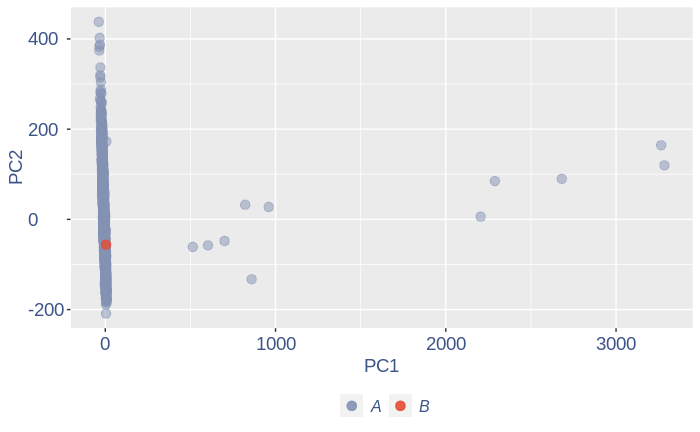

```r
obj = ttm$object

ttm$pca.cell.2
```

Run this when B cells need to be removed.

```r
pdf(paste(out_dir,"cleaning/",t,"_",n_it,"_plots_before_cells_exlusion.pdf", sep = ""))
ttm$pca.cell.2
ggplot(ttm$D, aes(x=n,y=means)) + geom_point() +
  geom_text_repel(data=subset(ttm$D, n > (max(ttm$D$n)- 15) ), aes(n,means,label=rownames(ttm$D[ttm$D$n > (max(ttm$D$n)- 15),])),
                  nudge_y      = 0.05,
                  nudge_x      = 0.05,
                  direction    = "x",
                  angle        = 90,
                  vjust        = 0,
                  segment.size = 0.2)+
  ggtitle("B cell group genes mean expression")+my_theme +
  theme(plot.title = element_text(color = "#3C5488FF", size = 20, face = "italic",vjust = - 5,hjust = 0.02 ))
```

```r
dev.off()
```

```r
if (length(ttm$cl1) < length(ttm$cl2)) {
  to_rem = ttm$cl1
}else{
  to_rem = ttm$cl2
}
n_it = n_it+1
obj@raw = obj@raw[,!colnames(obj@raw) %in% to_rem]
#obj@raw = obj@raw[rownames(obj@raw) %in% rownames(cells),colnames(obj@raw) %in% colnames(cells)]
gc()
```

```
            used   (Mb) gc trigger   (Mb)  max used   (Mb)
Ncells   4475665  239.1    6620478  353.6   6620478  353.6
Vcells 238508409 1819.7  614958257 4691.8 614957694 4691.8
```

```r
ttm = clean(obj)
```

```
[1] "Start estimation mu with linear method"
[1] 14017  2260
```

|  | rowname | X10X82_1_AACGATCCAAATGC. | X10X82_1_CGTAACATGGTTGT. | X10X82_1_GGGACAGGGAAACA. | X10X82_1_CCGCGCATCCCACT. | X10X82_1_ACAAGTCTCTTGAT. | X10X82_1_ACAACGTTCGCGAC. | X10X82_1_CTGGTAGGGCTTGA. | X10X82_1_GAGATGTTTCCACC. | X10X82_1_ACCTAGTCAAGCGA. | X10X82_1_ACGTCAGTACCGGA. | X10X82_1_TATTAGTTGCCTCT. | X10X82_1_CTACAGTCAGATAA. | X10X82_1_GATAGCAGATCGGA. | X10X82_1_TGGTAAGGGATGGG. | X10X82_1_GCCAGTCGTTTATC. | X10X82_1_GCAGCTCTACCTGC. | X10X82_1_GGAAGAGTGACTCT. | X10X82_1_GAGGCCAAACAACA. | X10X82_1_CCTAGTCGTTTATC. |
| --- | --- | --- | --- | --- | --- | --- | --- | --- | --- | --- | --- | --- | --- | --- | --- | --- | --- | --- | --- | --- |
| 12457 | Tmsb4x | 199.65195 | 126.27909 | 184.26045 | 130.06148 | 175.64457 | 315.05165 | 567.86441 | 447.42159 | 204.67841 | 323.97983 | 356.139043 | 332.88906 | 384.572816 | 259.33855 | 329.50380 | 230.75212 | 295.04100 | 251.13057 | 277.18811 |
| 4573 | Ftl1 | 140.93079 | 140.62899 | 178.53807 | 173.07394 | 119.11528 | 135.02214 | 126.04918 | 55.75771 | 215.77543 | 133.49169 | 76.403532 | 131.89944 | 53.248544 | 192.84148 | 198.69220 | 47.06129 | 60.31225 | 163.07985 | 181.90469 |
| 10421 | Rps29 | 74.86948 | 99.01429 | 86.98009 | 116.74810 | 94.88844 | 95.47020 | 82.96094 | 77.51681 | 57.33461 | 78.74510 | 69.009642 | 78.51157 | 79.544121 | 69.15695 | 103.23510 | 63.76045 | 83.13310 | 79.36966 | 61.09080 |
| 7045 | Malat1 | 71.93342 | 80.35942 | 25.17845 | 83.97670 | 57.53874 | 65.46528 | 61.09527 | 57.11765 | 40.68908 | 38.24762 | 178.685679 | 111.48643 | 40.100755 | 101.07554 | 46.66792 | 144.22007 | 125.51468 | 54.56664 | 37.38392 |
| 10364 | Rpl41 | 63.12525 | 51.65963 | 51.50137 | 70.66332 | 75.70887 | 68.87493 | 66.88324 | 70.71709 | 43.77159 | 58.49636 | 35.737136 | 56.52833 | 58.507659 | 46.54794 | 69.29479 | 48.57939 | 53.79201 | 71.92876 | 65.64981 |
| 1115 | Apoe | 149.73896 | 107.62422 | 76.67981 | 131.08558 | 86.81283 | 7.50123 | 11.57595 | 46.23810 | 43.15509 | 20.24874 | 3.696945 | 15.70231 | 9.203452 | 49.20783 | 40.30411 | 19.73538 | 14.67055 | 27.90340 | 32.36901 |
| 10405 | Rps19 | 51.38102 | 47.35466 | 44.63452 | 37.89193 | 47.44422 | 49.09896 | 37.30027 | 40.79832 | 48.08710 | 44.24725 | 44.363341 | 56.52833 | 48.646818 | 46.54794 | 50.91046 | 25.80780 | 32.60122 | 39.06476 | 45.59015 |
| 10351 | Rpl32 | 49.91299 | 34.43975 | 37.76767 | 45.06067 | 39.36861 | 57.28212 | 39.87270 | 66.63726 | 28.35906 | 47.24706 | 32.040191 | 58.09856 | 46.017260 | 31.91859 | 48.08210 | 44.02508 | 44.01164 | 34.72423 | 47.86966 |
| 10360 | Rpl37a | 39.63678 | 48.78965 | 49.21242 | 38.91603 | 33.31190 | 44.32545 | 34.72784 | 48.95799 | 32.05806 | 32.24799 | 36.969451 | 42.39625 | 38.128587 | 38.56830 | 41.01120 | 34.91644 | 42.38158 | 29.76362 | 28.26589 |
| 10333 | Rpl18a | 52.84905 | 28.69979 | 33.18977 | 40.96425 | 32.30245 | 38.87001 | 36.01405 | 44.87815 | 24.66005 | 40.49748 | 36.969451 | 48.67717 | 45.359871 | 18.61918 | 48.08210 | 45.54318 | 44.01164 | 36.58445 | 36.92802 |

[output cut: 5 more lines]

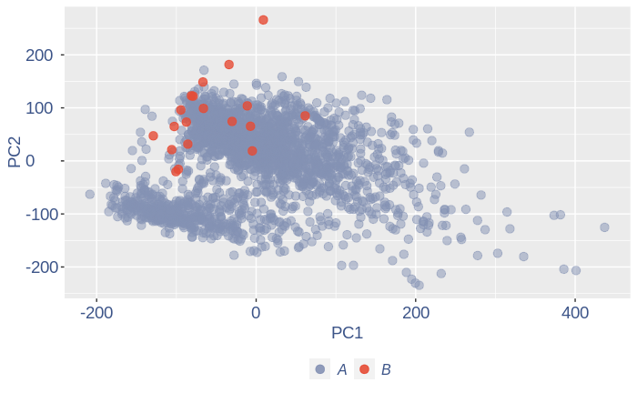

```r
#ttm = clean.sqrt(obj, cells)
obj = ttm$object

ttm$pca.cell.2
```

Run this only in the last iteration, instead the previus code, when B cells group has not to be removed

```r
pdf(paste(out_dir,"cleaning/",t,"_",n_it,"_plots_before_cells_exlusion.pdf", sep = ""))
ttm$pca.cell.2
ggplot(ttm$D, aes(x=n,y=means)) + geom_point() +
  geom_text_repel(data=subset(ttm$D, n > (max(ttm$D$n)- 15) ), aes(n,means,label=rownames(ttm$D[ttm$D$n > (max(ttm$D$n)- 15),])),
                  nudge_y      = 0.05,
                  nudge_x      = 0.05,
                  direction    = "x",
                  angle        = 90,
                  vjust        = 0,
                  segment.size = 0.2)+
  ggtitle(label = "B cell group genes mean expression", subtitle = " - B group NOT removed -")+my_theme +
  theme(plot.title = element_text(color = "#3C5488FF", size = 20, face = "italic",vjust = - 10,hjust = 0.02 ),
        plot.subtitle = element_text(color = "darkred",vjust = - 15,hjust = 0.01 ))
```

```r
dev.off()
```

To color the pca based on nu_j (so the cells’ efficiency)

```r
nu_est = round(obj@nu, digits = 7)

plot.nu <-ggplot(ttm$pca_cells,aes(x=PC1,y=PC2, colour = log(nu_est)))

plot.nu = plot.nu + geom_point(size = 1,alpha= 0.8)+
  scale_color_gradient2(low = "#E64B35B2",mid =  "#4DBBD5B2", high =  "#3C5488B2" ,
                        midpoint = log(mean(nu_est)),name = TeX(" $ln (\\nu) $ "))+
  ggtitle("Cells PCA coloured by cells efficiency") +
  my_theme +  theme(plot.title = element_text(color = "#3C5488FF", size = 20),
                    legend.title=element_text(color = "#3C5488FF", size = 14,face = "italic"),
                    legend.text = element_text(color = "#3C5488FF", size = 11),
                    legend.key.width = unit(2, "mm"),
                    legend.position="right")

pdf(paste(out_dir,"cleaning/",t,"_plots_PCA_efficiency_colored.pdf", sep = ""))
plot.nu
dev.off()
```

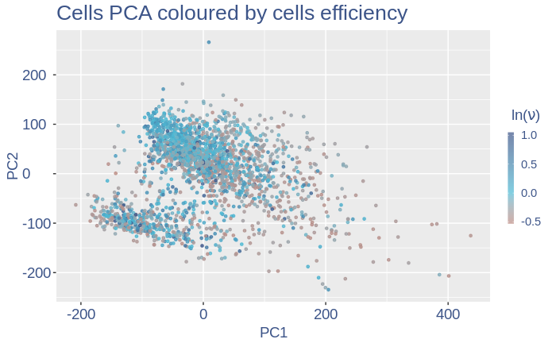

```r
plot.nu
```

The next part is use to remove the cells with efficiency too low.

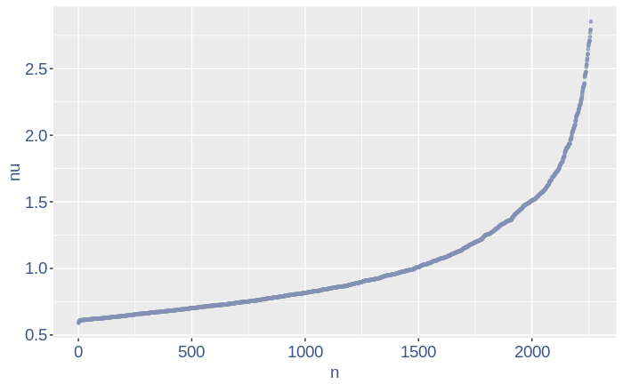

```r
nu_df = data.frame("nu"= sort(obj@nu), "n"=c(1:length(obj@nu)))

ggplot(nu_df, aes(x = n, y=nu)) +
    geom_point(colour = "#8491B4B2", size=1)+
    my_theme #+ ylim(0,1) + xlim(0,70)
```

We can zoom on the smalest values and, if we detect a clear elbow, we can decide to remove the cells.

```r
yset = 0.61#threshold to remove low UDE cells
plot.ude <- ggplot(nu_df, aes(x = n, y=nu)) +
    geom_point(colour = "#8491B4B2", size=1) +
    my_theme + ylim(0.5,1) + xlim(0,800) +
    geom_hline(yintercept=yset, linetype="dashed", color = "darkred") +
    annotate(geom="text", x=200, y=0.5,
             label=paste("to remove cells with nu < ",yset,sep = " "),
             color="darkred", size=4.5)


pdf(paste(out_dir,"cleaning/",t,"_plots_efficiency.pdf", sep = ""))
plot.ude
dev.off()
```

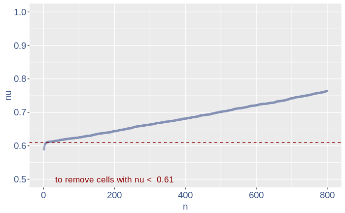

```r
plot.ude
```

We also save the defined treshold in the metadata and re run the estimation

```r
obj@meta[(nrow(obj@meta)+1),1:2] = c("Threshold low UDE cells:",yset)

to_rem = rownames(nu_df[which(nu_df$nu < yset),])
```

Repeat the estimation after the cells are removed

```r
ttm = clean(obj)
```

```
[1] "Start estimation mu with linear method"
[1] 14016  2252
```

|  | rowname | X10X82_1_AACGATCCAAATGC. | X10X82_1_CGTAACATGGTTGT. | X10X82_1_GGGACAGGGAAACA. | X10X82_1_CCGCGCATCCCACT. | X10X82_1_ACAAGTCTCTTGAT. | X10X82_1_ACAACGTTCGCGAC. | X10X82_1_CTGGTAGGGCTTGA. | X10X82_1_GAGATGTTTCCACC. | X10X82_1_ACCTAGTCAAGCGA. | X10X82_1_ACGTCAGTACCGGA. | X10X82_1_TATTAGTTGCCTCT. | X10X82_1_CTACAGTCAGATAA. | X10X82_1_GATAGCAGATCGGA. | X10X82_1_TGGTAAGGGATGGG. | X10X82_1_GCCAGTCGTTTATC. | X10X82_1_GCAGCTCTACCTGC. | X10X82_1_GGAAGAGTGACTCT. | X10X82_1_GAGGCCAAACAACA. | X10X82_1_CCTAGTCGTTTATC. |
| --- | --- | --- | --- | --- | --- | --- | --- | --- | --- | --- | --- | --- | --- | --- | --- | --- | --- | --- | --- | --- |
| 12456 | Tmsb4x | 199.93371 | 126.45730 | 184.52049 | 130.24503 | 175.89245 | 315.496274 | 568.66582 | 448.05302 | 204.96726 | 324.43705 | 356.641649 | 333.35885 | 385.115550 | 259.70454 | 329.96882 | 231.07777 | 295.45738 | 251.48498 | 277.57929 |
| 4573 | Ftl1 | 141.12968 | 140.82745 | 178.79004 | 173.31819 | 119.28338 | 135.212689 | 126.22707 | 55.83639 | 216.07994 | 133.68008 | 76.511357 | 132.08558 | 53.323691 | 193.11363 | 198.97261 | 47.12770 | 60.39736 | 163.31000 | 182.16141 |
| 10420 | Rps29 | 74.97514 | 99.15402 | 87.10284 | 116.91286 | 95.02236 | 95.604931 | 83.07802 | 77.62621 | 57.41553 | 78.85623 | 69.107032 | 78.62237 | 79.656379 | 69.25454 | 103.38079 | 63.85044 | 83.25042 | 79.48167 | 61.17701 |
| 7045 | Malat1 | 72.03494 | 80.47283 | 25.21398 | 84.09522 | 57.61994 | 65.557667 | 61.18149 | 57.19826 | 40.74650 | 38.30160 | 178.937852 | 111.64377 | 40.157348 | 101.21818 | 46.73378 | 144.42361 | 125.69181 | 54.64365 | 37.43668 |
| 10363 | Rpl41 | 63.21434 | 51.73253 | 51.57405 | 70.76305 | 75.81571 | 68.972129 | 66.97763 | 70.81689 | 43.83336 | 58.57891 | 35.787570 | 56.60811 | 58.590229 | 46.61364 | 69.39258 | 48.64795 | 53.86792 | 72.03027 | 65.74246 |
| 1115 | Apoe | 149.95028 | 107.77611 | 76.78803 | 131.27058 | 86.93535 | 7.511816 | 11.59228 | 46.30335 | 43.21599 | 20.27732 | 3.702162 | 15.72447 | 9.216441 | 49.27727 | 40.36099 | 19.76323 | 14.69125 | 27.94278 | 32.41469 |
| 10404 | Rps19 | 51.45353 | 47.42149 | 44.69751 | 37.94540 | 47.51118 | 49.168250 | 37.35291 | 40.85590 | 48.15496 | 44.30969 | 44.425949 | 56.60811 | 48.715471 | 46.61364 | 50.98231 | 25.84422 | 32.64722 | 39.11989 | 45.65449 |
| 10350 | Rpl32 | 49.98343 | 34.48836 | 37.82097 | 45.12426 | 39.42417 | 57.362959 | 39.92897 | 66.73130 | 28.39908 | 47.31374 | 32.085408 | 58.18055 | 46.082203 | 31.96364 | 48.14996 | 44.08721 | 44.07375 | 34.77323 | 47.93721 |
| 10359 | Rpl37a | 39.69272 | 48.85850 | 49.28187 | 38.97095 | 33.35891 | 44.388004 | 34.77685 | 49.02708 | 32.10331 | 32.29350 | 37.021625 | 42.45608 | 38.182396 | 38.62273 | 41.06908 | 34.96572 | 42.44139 | 29.80563 | 28.30578 |
| 10332 | Rpl18a | 52.92363 | 28.74030 | 33.23661 | 41.02206 | 32.34804 | 38.924865 | 36.06488 | 44.94149 | 24.69485 | 40.55463 | 37.021625 | 48.74587 | 45.423885 | 18.64545 | 48.14996 | 45.60745 | 44.07375 | 36.63608 | 36.98014 |

[output cut: 5 more lines]

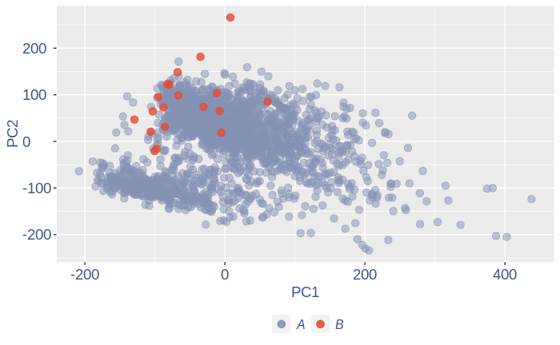

```r
obj = ttm$object
ttm$pca.cell.2
```

In case we do not want to remove anything, we can run:

```r
pdf(paste(out_dir,"cleaning/",t,"_plots_efficiency.pdf", sep = ""))
ggplot(nu_df, aes(x = n, y=nu)) + geom_point(colour = "#8491B4B2", size=1) +my_theme + #xlim(0,100)+
  annotate(geom="text", x=50, y=0.25, label="nothing to remove ", color="darkred")
dev.off()
```

Just to check again, we plot the final efficiency colored PCA

```r
nu_est = round(obj@nu, digits = 7)
plot.nu <-ggplot(ttm$pca_cells,aes(x=PC1,y=PC2, colour = log(nu_est)))
plot.nu = plot.nu + geom_point(size = 2,alpha= 0.8)+
  scale_color_gradient2(low = "#E64B35B2",mid =  "#4DBBD5B2", high =  "#3C5488B2" ,
                        midpoint = log(mean(nu_est)),name = TeX(" $ln (\\nu) $ "))+
  ggtitle("Cells PCA coloured by cells efficiency: last") +
  my_theme +  theme(plot.title = element_text(color = "#3C5488FF", size = 20),
                    legend.title=element_text(color = "#3C5488FF", size = 14,face = "italic"),
                    legend.text = element_text(color = "#3C5488FF", size = 11),
                    legend.key.width = unit(2, "mm"),
                    legend.position="right")

pdf(paste(out_dir,"cleaning/",t,"_plots_PCA_efficiency_colored_FINAL.pdf", sep = ""))
plot.nu
dev.off()
```

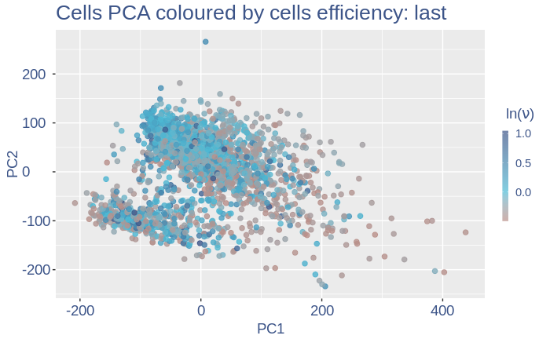

```r
plot.nu
```

COTAN analysis: in this part all the contingency tables are computed and used to get the statistics (S) To storage efficincy of all the observed tables only the yes_yes is stored. Note that if will be necessary re-coputing the yes-yes table, the yes-yes table should be cancelled before running cotan_analysis.

```r
# obj@yes_yes = c()
obj = cotan_analysis(obj)
```

```
[1] "cotan analysis"
[1] "mu estimator creation"
[1] "save effective constitutive genes"
[1] "start a minimization"
[1] "Next gene: C030010L15Rik number 1810"
[1] "Next gene: Eif5 number 3820"
[1] "Next gene: Hif1an number 5830"
[1] "Next gene: Nanos3 number 7840"
[1] "Next gene: Rai14 number 9850"
[1] "Next gene: Tango6 number 11860"
[1] "Next gene: Zfyve9 number 13870"
[1] "Final trance!"
[1] "a min: -0.16064453125 | a max 655.75 | negative a %: 24.6272935779816"
```

COEX evaluation and storing

```r
saveRDS(obj,file = paste(out_dir,t,".cotan.RDS", sep = ""))

obj = get.coex(obj)
```

```
[1] "coex dataframe creation"
[1] "Generating contingency tables for observed data"
[1] "creation of observed yes/yes contingency table"
[1] "mu estimator creation"
[1] "expected contingency tables creation"
[1] "The distance between estimated n of zeros and observed number of zero is 0.0645044010582986 over 13952"
[1] "Done"
[1] "coex estimation"
[1] "Diagonal coex values substituted with 0"
```

```r
# saving the structure
saveRDS(obj,file = paste(out_dir,t,".cotan.RDS", sep = ""))
```

## 0.3 Analysis of the elaborated data

### 0.3.1 GDI

The next function can directly plot the GDI for the dataset with the 1.5 threshold (in red) and the two higher quantiles (in blue).

```
[1] "GDI plot "
[1] "function to generate GDI dataframe"
[1] "Using S"
[1] "function to generate S "
```

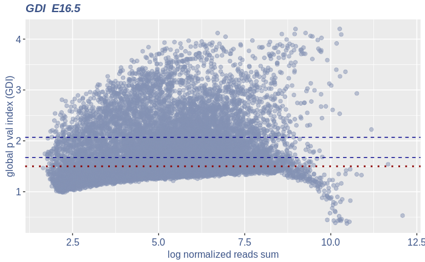

```r
obj = readRDS("Data/E16.5_cleaned.cotan.RDS")
plot.GDI(obj, cond = "E16.5")
```

If a more complex plot is needed, or if we want to analize mor in detail the GDI data, we can get direcly the GDI dataframe.

|  | sum.raw.norm | GDI | exp.cells |
| --- | --- | --- | --- |
| 0610007P14Rik | 7.767911 | 1.747306 | 61.101243 |
| 0610009B22Rik | 7.479196 | 1.455147 | 52.131439 |
| 0610009L18Rik | 5.790959 | 1.566397 | 13.055062 |
| 0610009O20Rik | 5.355500 | 1.939768 | 8.614565 |
| 0610010F05Rik | 7.333657 | 2.940365 | 44.138544 |
| 0610010K14Rik | 7.408325 | 1.521350 | 49.555950 |

In the third column of this dataframe is reported the percentage of cells expressing the gene.

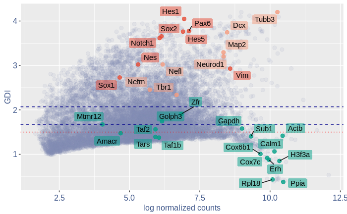

```r
NPGs=c("Nes","Vim","Sox2","Sox1","Notch1", "Hes1","Hes5","Pax6") #,"Hes3"
PNGs=c("Map2","Tubb3","Neurod1","Nefm","Nefl","Dcx","Tbr1")
hk=c("Calm1","Cox6b1","Ppia","Rpl18","Cox7c","Erh","H3f3a","Taf1b","Taf2","Gapdh","Actb","Golph3", "Mtmr12", "Zfr", "Sub1", "Tars", "Amacr")

text.size = 12

quant.p$highlight = with(quant.p, ifelse(rownames(quant.p) %in% NPGs, "NPGs",
                                                 ifelse(rownames(quant.p) %in% hk,"Constitutive" ,
                                                               ifelse(rownames(quant.p) %in% PNGs,"PNGs" , "normal"))))

textdf <- quant.p[rownames(quant.p) %in% c(NPGs,hk,PNGs), ]
mycolours <- c("Constitutive" = "#00A087FF","NPGs"="#E64B35FF","PNGs"="#F39B7FFF","normal" = "#8491B4B2")
f1 = ggplot(subset(quant.p,highlight == "normal" ), aes(x=sum.raw.norm, y=GDI)) +  geom_point(alpha = 0.1, color = "#8491B4B2", size=2.5)
GDI_plot = f1 +  geom_point(data = subset(quant.p,highlight != "normal"  ), aes(x=sum.raw.norm, y=GDI, colour=highlight),size=2.5,alpha = 0.8) +
  geom_hline(yintercept=quantile(quant.p$GDI)[4], linetype="dashed", color = "darkblue") +
  geom_hline(yintercept=quantile(quant.p$GDI)[3], linetype="dashed", color = "darkblue") +
  geom_hline(yintercept=1.5, linetype="dotted", color = "red", size= 0.5) +
  scale_color_manual("Status", values = mycolours)  +
  scale_fill_manual("Status", values = mycolours)  +
  xlab("log normalized counts")+ylab("GDI")+
  geom_label_repel(data =textdf , aes(x=sum.raw.norm, y=GDI, label = rownames(textdf),fill=highlight),
                   label.size = NA,
                   alpha = 0.5,
                   direction ="both",
                   na.rm=TRUE,
                   seed = 1234) +
  geom_label_repel(data =textdf , aes(x=sum.raw.norm, y=GDI, label = rownames(textdf)),
                   label.size = NA,
                   segment.color = 'black',
                   segment.size = 0.5,
                   direction = "both",
                   alpha = 0.8,
                   na.rm=TRUE,
                   fill = NA,
                   seed = 1234) +
  theme(axis.text.x = element_text(size = text.size, angle = 0, hjust = .5, vjust = .5, face = "plain", colour ="#3C5488FF" ),
        axis.text.y = element_text( size = text.size, angle = 0, hjust = 0, vjust = .5, face = "plain", colour ="#3C5488FF"),
        axis.title.x = element_text( size = text.size, angle = 0, hjust = .5, vjust = 0, face = "plain", colour ="#3C5488FF"),
        axis.title.y = element_text( size = text.size, angle = 90, hjust = .5, vjust = .5, face = "plain", colour ="#3C5488FF"),
        legend.title = element_blank(),
        legend.text = element_text(color = "#3C5488FF",face ="italic" ),
        legend.position = "bottom")  # titl)
legend <- cowplot::get_legend(GDI_plot)
GDI_plot =GDI_plot + theme(
        legend.position = "none")
GDI_plot
```

### 0.3.2 Heatmaps

```
[1] "plot heatmap"
[1] "Loading condition E16.5_cleaned"
[1] "Map2"    "Tubb3"   "Neurod1" "Nefm"    "Nefl"    "Dcx"     "Tbr1"
[1] "Get p-values on a set of genes on columns on a set of genes on rows"
[1] "Using function S"
[1] "function to generate S "
[1] "Ref.col"
[1] "NPGs"
[1] "Const."
[1] "min coex: -0.012172718763187 max coex 0.00986310255906158"
```

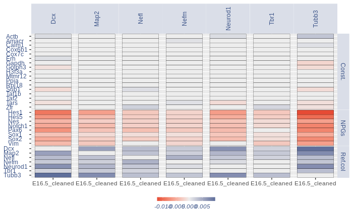

```r
list.genes = list("Ref.col"= PNGs, "NPGs"=NPGs, "Const."=hk )

plot.heatmap(df_genes = list.genes,sets = c(1:3),conditions = "E16.5_cleaned",dir = "Data/")
```